# Seminarska naloga - vizualizacija podatkov

Neža Kržan, Tom Rupnik Medjedovič

**Predstavitev števila umrlih glede na različne vzroke po kohezijskih regijah v Sloveniji.**

**Podatki so pridobljeni od leta 2002 do leta 2022, razen pri enem vzroku so beleženi šele od leta 2020 naprej. Vsebujejo število umrlih glede na celotno Slovenijo, Vzhodni in Zahodni del ter so ločeni tudi glede na spol. Vsebujejo skupno število umrlih in glede na 6 različnih vzrokov.**

### Število smrti glede na vzrok

**Graf je namenjen splošnemu pregledu umrljivosti v Sloveniji glede na vzrok smrti.**

[interactive chart not shown]

Vir: Podatkovna baza SiStat. Prebivalstvo/Rojeni in umrli/Vzrok smrti. Dostopno na URL: https://pxweb.stat.si/SiStatData/pxweb/sl/Data/-/05L3013S.px.

### Število umrlih žensk in moških po vzroku

**Graf je namenjen prikazu razlik števila umrlih med moškimi in ženskami, glede na vzrok.**

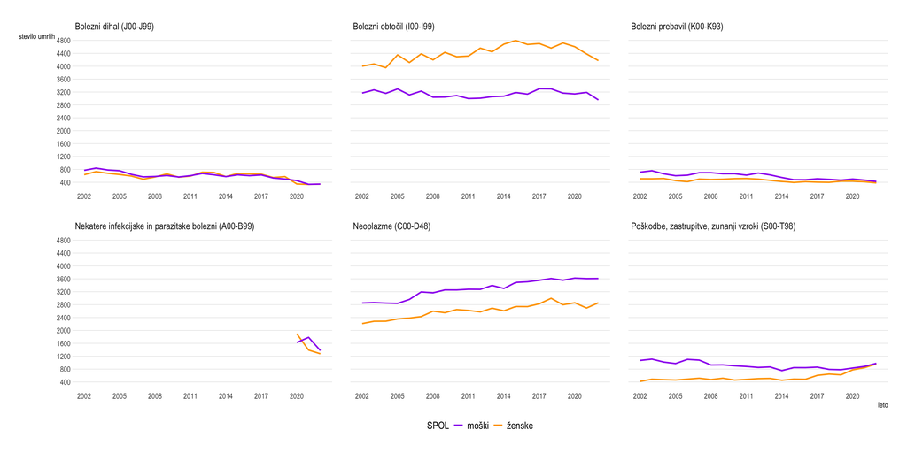

Vir: Podatkovna baza SiStat. Prebivalstvo/Rojeni in umrli/Vzrok smrti. Dostopno na URL: https://pxweb.stat.si/SiStatData/pxweb/sl/Data/-/05L3013S.px.

### Delež smrti glede na vzrok po kohezijskih regijah

**Graf je namenjen podrobnejšemu pregledu deleža umrlih glede na vzrok po kohezijskih Regijah. Graf lahko spreminjamo glede na leta in glede na spol.**

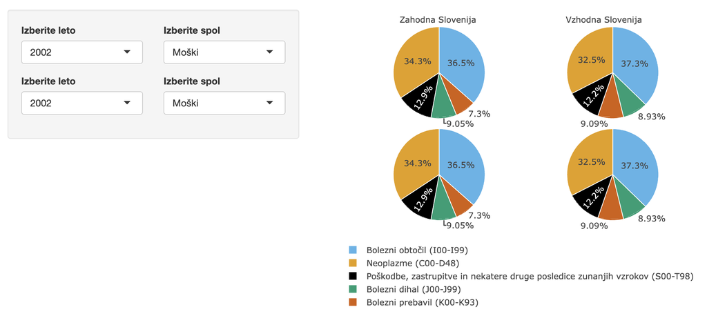

Vir: Podatkovna baza SiStat. Prebivalstvo/Rojeni in umrli/Vzrok smrti. Dostopno na URL: https://pxweb.stat.si/SiStatData/pxweb/sl/Data/-/05L3013S.px.

Za interaktivni graf kliknite [POVEZAVO](https://mybinder.org/v2/gh/tomrupnik/grafi_binder/main?urlpath=shiny/prikaz_graf3.Rmd) .